# CMPS Project M1

**Socioeconomic Effects of Air Quality Compliance: Milestone 1 Submission**

By Peter Carroll

**Project Overview**: This project aims to investigate potential relationships between air quality—specifically PM2.5 (Particulate Matter) levels—and employment metrics across U.S. states. The following data used are publicly available datasets from the EPA Air Quality System (AQS) and the Bureau of Labor Statistics (BLS). I will assess trends in both environmental and labor market data. We selected these datasets for their relevance, size, and public accessibility, with potential room for expansion to public health outcomes. The EPA’s dataset provides granular PM2.5 measurements at the county level, while the BLS data provides state-level employment figures, including total employment and average annual wages across industries. While the datasets differ in spatial resolution (state vs. county), they offer an opportunity to explore side-by-side trends and insights in the exploratory phase of this project. If time permits, I would like to examine specific county level trends overtime. Furthermore, I would like to examine which specific industries lead to the most particulate matter emissions. However, for this milestone 1 submission, I decided to look at trends on the state level.

Initial research question: How do trends in fine particulate matter (PM2.5) concentrations relate to economic indicators such as employment levels and average wages, speciifcally in manufacturing industries, across different U.S. states?

Questions for each data set:

EPA AQS - PM2.5 Data (2018) Question: Which states have the highest and lowest average PM2.5 concentrations in 2018?

BLS State Occupational Employment and Wage Estimates (2018) Question: How do total employment and average wages vary by state and industry?

Question for merged data set: Are there noticeable trends/correlations between particulate matter emissions and industrial output?

**Set Up**

```python
# Install necessary packages and libraries
!pip install xlrd
import pandas as pd
import numpy as np
import matplotlib.pyplot as plt
import seaborn as sns

# Mount Drive
from google.colab import drive
drive.mount('/content/drive')
```

```python
# Load datasets from Google Drive
pm25_path = '/content/drive/MyDrive/CMPS Project Data/annual_conc_by_monitor_2018.csv'
bls_path = '/content/drive/MyDrive/CMPS Project Data/state_M2018_dl.xlsx'

df_pm25 = pd.read_csv(pm25_path)
df_bls_state = pd.read_excel(bls_path, skiprows=4)
```

**Data Cleaning- BLS**

```python
# Clean BLS data
#Rename columns for clarity
df_bls_state.columns = [
    'state_code', 'state_abbr', 'state_name', 'occupation_code', 'occupation_title',
    'level', 'employment', 'employment_RSE', 'emp_per_1000_jobs', 'location_quotient',
    'median_hourly_wage', 'mean_hourly_wage', 'annual_mean_wage', 'percentile_10_hourly',
    'percentile_25_hourly', 'percentile_50_hourly', 'percentile_75_hourly', 'percentile_90_hourly',
    'annual_10th', 'annual_25th', 'annual_median', 'annual_75th', 'annual_90th', 'footnote_1', 'footnote_2'
]

# Clean numeric columns
for col in ['employment', 'annual_mean_wage']:
    df_bls_state[col] = df_bls_state[col].replace(['*', '**', '#'], pd.NA)
    df_bls_state[col] = df_bls_state[col].astype(str).str.replace(',', '', regex=False)
    df_bls_state[col] = pd.to_numeric(df_bls_state[col], errors='coerce')

# Filter for manufacturing-related occupations
manufacturing_keywords = ['Production', 'Plant', 'Industrial', 'Machinist', 'Assembler', 'Machine', 'Operator']
df_mfg = df_bls_state[
    df_bls_state['occupation_title'].str.contains('|'.join(manufacturing_keywords), case=False, na=False)
]

df_mfg = df_mfg.dropna(subset=['employment', 'annual_mean_wage'])
```

```python
# Aggregate manufacturing employment by state
df_mfg_agg = df_mfg.groupby('state_name').agg({
    'employment': 'sum',
    'annual_mean_wage': 'mean'
}).reset_index()
```

```python
df_mfg.head()
```

|  | state_code | state_abbr | state_name | occupation_code | occupation_title | level | employment | employment_RSE | emp_per_1000_jobs | location_quotient | ... | percentile_50_hourly | percentile_75_hourly | percentile_90_hourly | annual_10th | annual_25th | annual_median | annual_75th | annual_90th | footnote_1 | footnote_2 |
| --- | --- | --- | --- | --- | --- | --- | --- | --- | --- | --- | --- | --- | --- | --- | --- | --- | --- | --- | --- | --- | --- |
| 8 | 1 | AL | Alabama | 11-3051 | Industrial Production Managers | detailed | 3530.0 | 4 | 1.817 | 1.45 | ... | 46.52 | 59.23 | 76.03 | 60030 | 76330 | 96770 | 123200 | 158150 | NaN | NaN |
| 89 | 1 | AL | Alabama | 17-2112 | Industrial Engineers | detailed | 5630.0 | 2.9 | 2.897 | 1.5 | ... | 40.65 | 49.66 | 61.12 | 55230 | 68780 | 84540 | 103290 | 127130 | NaN | NaN |
| 106 | 1 | AL | Alabama | 17-3026 | Industrial Engineering Technicians | detailed | 1030.0 | 9 | 0.528 | 1.15 | ... | 25 | 31.45 | 38.14 | 33130 | 41650 | 52010 | 65410 | 79330 | NaN | NaN |
| 112 | 1 | AL | Alabama | 19-1013 | Soil and Plant Scientists | detailed | 50.0 | 5.7 | 0.025 | 0.24 | ... | 27.01 | 37.29 | 46.19 | 37880 | 44770 | 56180 | 77560 | 96080 | NaN | NaN |
| 236 | 1 | AL | Alabama | 27-1021 | Commercial and Industrial Designers | detailed | 180.0 | 7.9 | 0.092 | 0.4 | ... | 30.85 | 39.52 | 46.63 | 34020 | 51000 | 64170 | 82200 | 97000 | NaN | NaN |

5 rows × 25 columns

```python
# Basic statistics
df_mfg[['employment', 'annual_mean_wage']].describe()
```

|  | employment | annual_mean_wage |
| --- | --- | --- |
| count | 4036.000000 | 4036.000000 |
| mean | 4655.686323 | 3.805649 |
| std | 28621.403597 | 2.436501 |
| min | 30.000000 | 0.400000 |
| 25% | 220.000000 | 2.200000 |
| 50% | 670.000000 | 3.200000 |
| 75% | 2140.000000 | 4.700000 |
| max | 836260.000000 | 28.000000 |

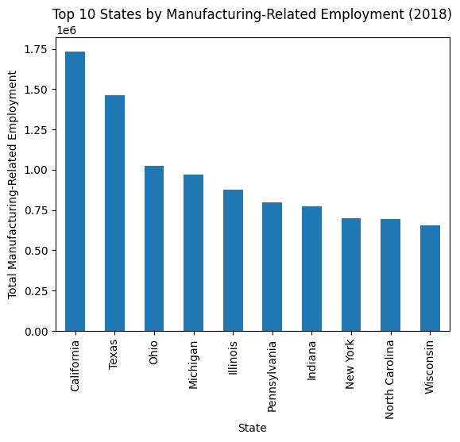

```python
# Bar plot for manufacturing by state
df_state_agg = df_mfg_agg.groupby('state_name')['employment'].sum().dropna().sort_values(ascending=False).head(10)

df_state_agg.plot(kind='bar')
plt.ylabel('Total Manufacturing-Related Employment')
plt.xlabel('State')
plt.title('Top 10 States by Manufacturing-Related Employment (2018)')
plt.show()
```

**PM2.5 Cleaning and EDA**

```python
# Clean PM2.5 data
df_pm25_clean = df_pm25[df_pm25['Parameter Name'] == 'PM2.5 - Local Conditions']
df_pm25_clean = df_pm25_clean[['State Name', 'Arithmetic Mean']].dropna()
```

```python
# Aggregate PM2.5 by state (mean concentration)
df_pm25_agg = df_pm25_clean.groupby('State Name')['Arithmetic Mean'].mean().reset_index()
df_pm25_agg.columns = ['state_name', 'avg_pm25']

df_pm25_agg.head()
```

|  | state_name | avg_pm25 |
| --- | --- | --- |
| 0 | Alabama | 8.517442 |
| 1 | Alaska | 7.966343 |
| 2 | Arizona | 7.948104 |
| 3 | Arkansas | 8.780321 |
| 4 | California | 10.470187 |

```python
# Merge Datasets
df_merged = pd.merge(df_mfg_agg, df_pm25_agg, on='state_name', how='inner')

df_merged.head()
```

|  | state_name | employment | annual_mean_wage | avg_pm25 |
| --- | --- | --- | --- | --- |
| 0 | Alabama | 430410.0 | 3.841304 | 8.517442 |
| 1 | Alaska | 22660.0 | 5.372093 | 7.966343 |
| 2 | Arizona | 238640.0 | 3.864557 | 7.948104 |
| 3 | Arkansas | 231890.0 | 3.965854 | 8.780321 |
| 4 | California | 1732940.0 | 2.974227 | 10.470187 |

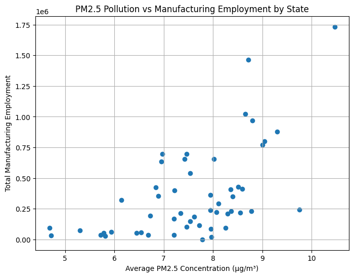

|  | avg_pm25 | employment | annual_mean_wage |
| --- | --- | --- | --- |
| avg_pm25 | 1.000000 | 0.574466 | -0.204259 |
| employment | 0.574466 | 1.000000 | -0.602805 |
| annual_mean_wage | -0.204259 | -0.602805 | 1.000000 |

```python
# Scatter plot: PM2.5 vs Manufacturing Employment
plt.figure(figsize=(8,6))
plt.scatter(df_merged['avg_pm25'], df_merged['employment'])
plt.xlabel('Average PM2.5 Concentration (µg/m³)')
plt.ylabel('Total Manufacturing Employment')
plt.title('PM2.5 Pollution vs Manufacturing Employment by State')
plt.grid(True)
plt.show()

# Correlation matrix
df_merged[['avg_pm25', 'employment', 'annual_mean_wage']].corr()
```

[output not shown]